# Intrinsic Rewards are domain general and related to mental health

### Experiment 2

#### Intrinsic reward factorisation

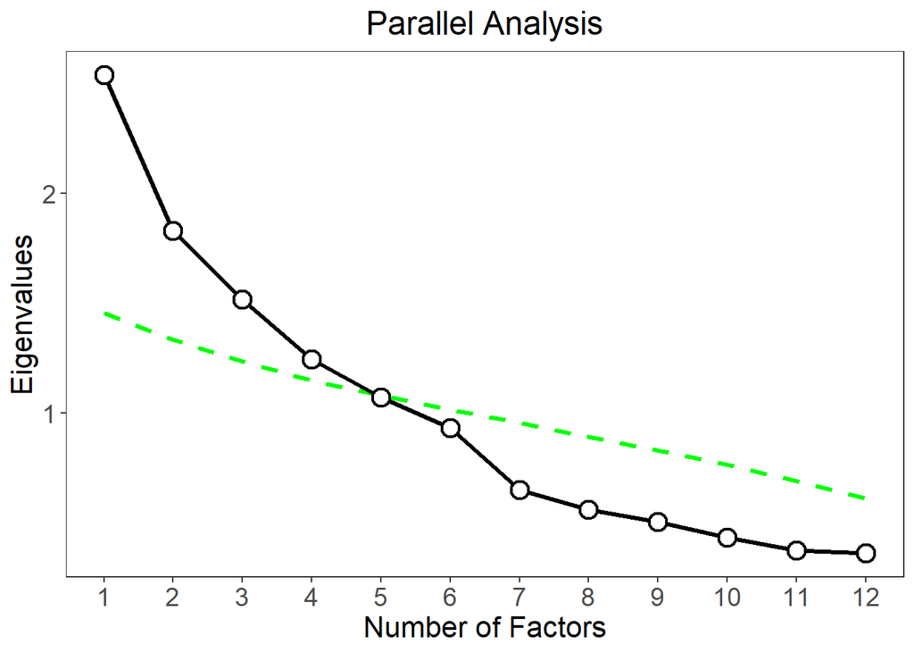

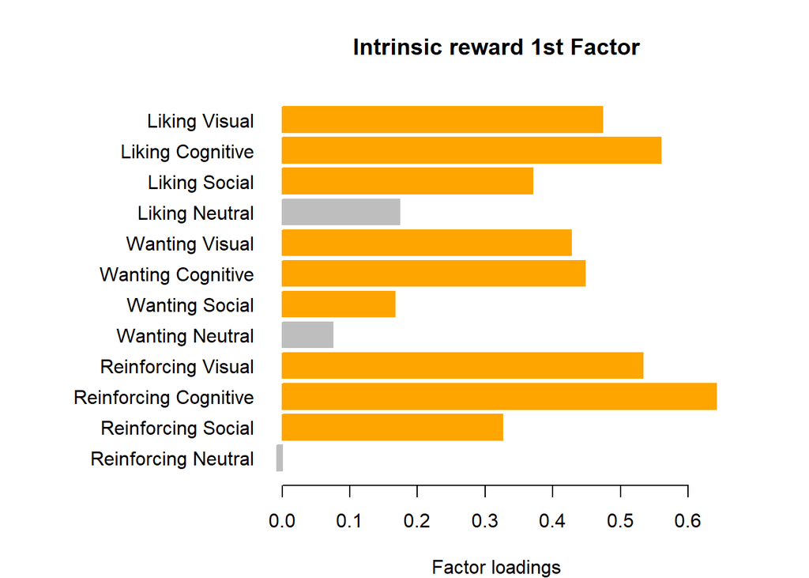

#### Monetary reward factorisation

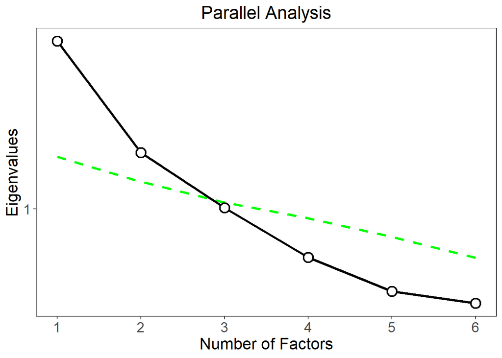

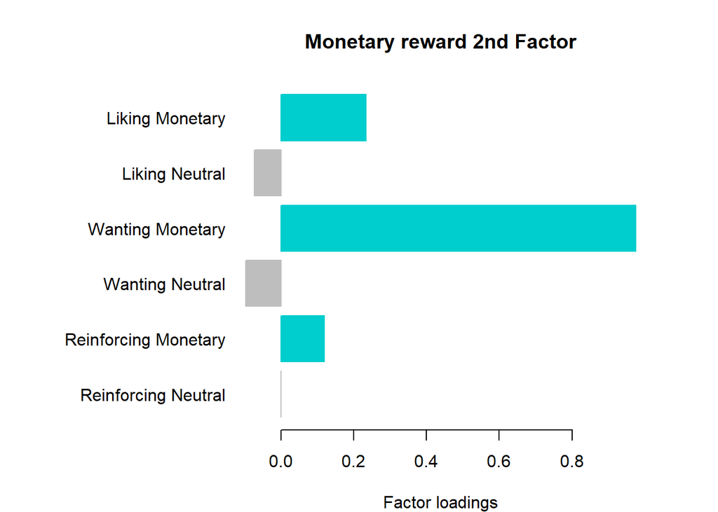

#### Relation to mental health

```
##
## Call:
## lm(formula = mentalHealth_NoOutlier ~ gender + age + iq + edu +
##     income + irSensitivity_NoOutlier + mrSensitivity_NoOutlier,
##     data = df)
##
## Residuals:
##     Min      1Q  Median      3Q     Max
## -1.7184 -0.4353  0.1407  0.5314  1.3742
##
## Coefficients:
##                          Estimate Std. Error t value Pr(>|t|)
## (Intercept)             -0.289999   0.204866  -1.416  0.15903
## gender                   0.006358   0.112957   0.056  0.95519
## age                      0.008525   0.004059   2.100  0.03742 *
## iq                      -0.045303   0.018141  -2.497  0.01362 *
## edu                      0.103441   0.036946   2.800  0.00581 **
## income                   0.061344   0.028392   2.161  0.03236 *
## irSensitivity_NoOutlier  0.226553   0.068421   3.311  0.00117 **
## mrSensitivity_NoOutlier  0.006877   0.092778   0.074  0.94102
## ---
## Signif. codes:  0 '***' 0.001 '**' 0.01 '*' 0.05 '.' 0.1 ' ' 1
##
## Residual standard error: 0.6836 on 146 degrees of freedom
##   (1 observation deleted due to missingness)
## Multiple R-squared:  0.2215, Adjusted R-squared:  0.1842
## F-statistic: 5.934 on 7 and 146 DF,  p-value: 4.369e-06
```

```
##
## Call:
## lm(formula = mentalHealth_NoOutlier ~ irSensitivity_NoOutlier +
##     mrSensitivity_NoOutlier, data = df)
##
## Residuals:
##      Min       1Q   Median       3Q      Max
## -2.20583 -0.51639  0.02706  0.60771  1.34753
##
## Coefficients:
##                         Estimate Std. Error t value Pr(>|t|)
## (Intercept)              0.11807    0.06143   1.922   0.0565 .
## irSensitivity_NoOutlier  0.20230    0.07183   2.816   0.0055 **
## mrSensitivity_NoOutlier  0.02232    0.09992   0.223   0.8235
## ---
## Signif. codes:  0 '***' 0.001 '**' 0.01 '*' 0.05 '.' 0.1 ' ' 1
##
## Residual standard error: 0.7457 on 152 degrees of freedom
## Multiple R-squared:  0.05121,    Adjusted R-squared:  0.03873
## F-statistic: 4.102 on 2 and 152 DF,  p-value: 0.0184
```

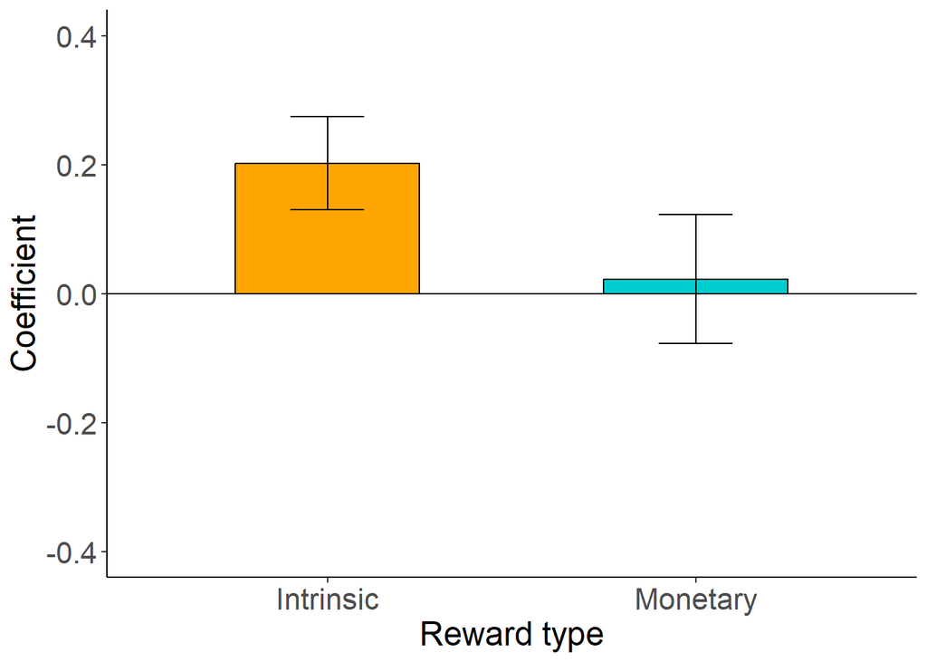

```
##
## Call:
## lm(formula = mentalHealth_NoOutlier ~ irSensitivity_NoOutlier,
##     data = df)
##
## Residuals:
##      Min       1Q   Median       3Q      Max
## -2.20674 -0.51278  0.03466  0.60674  1.35714
##
## Coefficients:
##                         Estimate Std. Error t value Pr(>|t|)
## (Intercept)              0.12108    0.05976   2.026  0.04448 *
## irSensitivity_NoOutlier  0.20398    0.07121   2.865  0.00476 **
## ---
## Signif. codes:  0 '***' 0.001 '**' 0.01 '*' 0.05 '.' 0.1 ' ' 1
##
## Residual standard error: 0.7434 on 153 degrees of freedom
## Multiple R-squared:  0.0509, Adjusted R-squared:  0.0447
## F-statistic: 8.205 on 1 and 153 DF,  p-value: 0.004764
```

```
##
## Call:
## lm(formula = mentalHealth_NoOutlier ~ gender + age + iq + edu +
##     income + irSensitivity_NoOutlier, data = df)
##
## Residuals:
##     Min      1Q  Median      3Q     Max
## -1.7200 -0.4444  0.1384  0.5330  1.3752
##
## Coefficients:
##                          Estimate Std. Error t value Pr(>|t|)
## (Intercept)             -0.289360   0.203991  -1.418  0.15816
## gender                   0.006907   0.112332   0.061  0.95105
## age                      0.008537   0.004042   2.112  0.03637 *
## iq                      -0.045335   0.018074  -2.508  0.01322 *
## edu                      0.103159   0.036625   2.817  0.00552 **
## income                   0.061605   0.028077   2.194  0.02979 *
## irSensitivity_NoOutlier  0.227024   0.067894   3.344  0.00105 **
## ---
## Signif. codes:  0 '***' 0.001 '**' 0.01 '*' 0.05 '.' 0.1 ' ' 1
##
## Residual standard error: 0.6813 on 147 degrees of freedom
##   (1 observation deleted due to missingness)
## Multiple R-squared:  0.2215, Adjusted R-squared:  0.1897
## F-statistic: 6.969 on 6 and 147 DF,  p-value: 1.549e-06
```

```
##
## Call:
## lm(formula = mentalHealth_NoOutlier ~ mrSensitivity_NoOutlier,
##     data = df)
##
## Residuals:
##      Min       1Q   Median       3Q      Max
## -2.16729 -0.51225  0.05929  0.61277  1.29237
##
## Coefficients:
##                         Estimate Std. Error t value Pr(>|t|)
## (Intercept)              0.12055    0.06280   1.919   0.0568 .
## mrSensitivity_NoOutlier  0.05186    0.10159   0.510   0.6105
## ---
## Signif. codes:  0 '***' 0.001 '**' 0.01 '*' 0.05 '.' 0.1 ' ' 1
##
## Residual standard error: 0.7624 on 153 degrees of freedom
## Multiple R-squared:  0.0017, Adjusted R-squared:  -0.004825
## F-statistic: 0.2606 on 1 and 153 DF,  p-value: 0.6105
```

```
##
## Call:
## lm(formula = mentalHealth_NoOutlier ~ gender + age + iq + edu +
##     income + mrSensitivity_NoOutlier, data = df)
##
## Residuals:
##     Min      1Q  Median      3Q     Max
## -1.8159 -0.4302  0.1008  0.5257  1.3615
##
## Coefficients:
##                          Estimate Std. Error t value Pr(>|t|)
## (Intercept)             -0.418649   0.207853  -2.014   0.0458 *
## gender                   0.032208   0.116443   0.277   0.7825
## age                      0.008551   0.004194   2.039   0.0433 *
## iq                      -0.030923   0.018200  -1.699   0.0914 .
## edu                      0.100745   0.038169   2.639   0.0092 **
## income                   0.066259   0.029298   2.262   0.0252 *
## mrSensitivity_NoOutlier  0.035431   0.095455   0.371   0.7110
## ---
## Signif. codes:  0 '***' 0.001 '**' 0.01 '*' 0.05 '.' 0.1 ' ' 1
##
## Residual standard error: 0.7064 on 147 degrees of freedom
##   (1 observation deleted due to missingness)
## Multiple R-squared:  0.163,  Adjusted R-squared:  0.1289
## F-statistic: 4.772 on 6 and 147 DF,  p-value: 0.0001789
```

```
## [1] 351.9627
```

```
## [1] 363.1076
```

```
## [1] 0
```

```
## [1] 11.14495
```

```
## [1] 361.0712
```

```
## [1] 368.9049
```

```
## [1] 0
```

```
## [1] 7.833688
```

### Experiment 3

#### Intrinsic reward factorisation

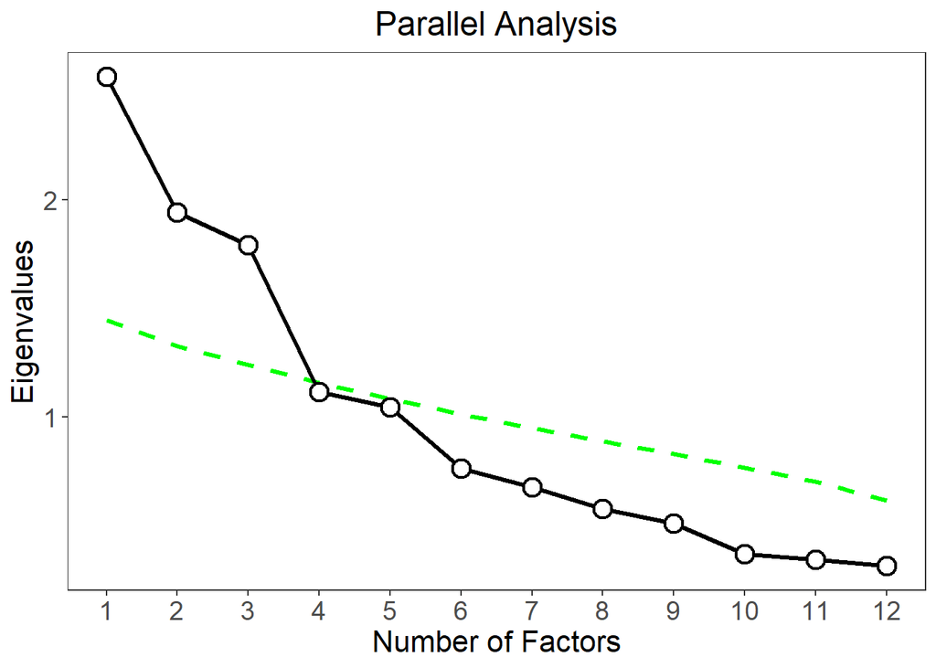

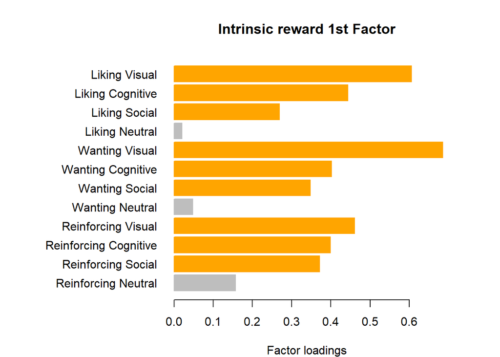

#### Monetary reward factorisation

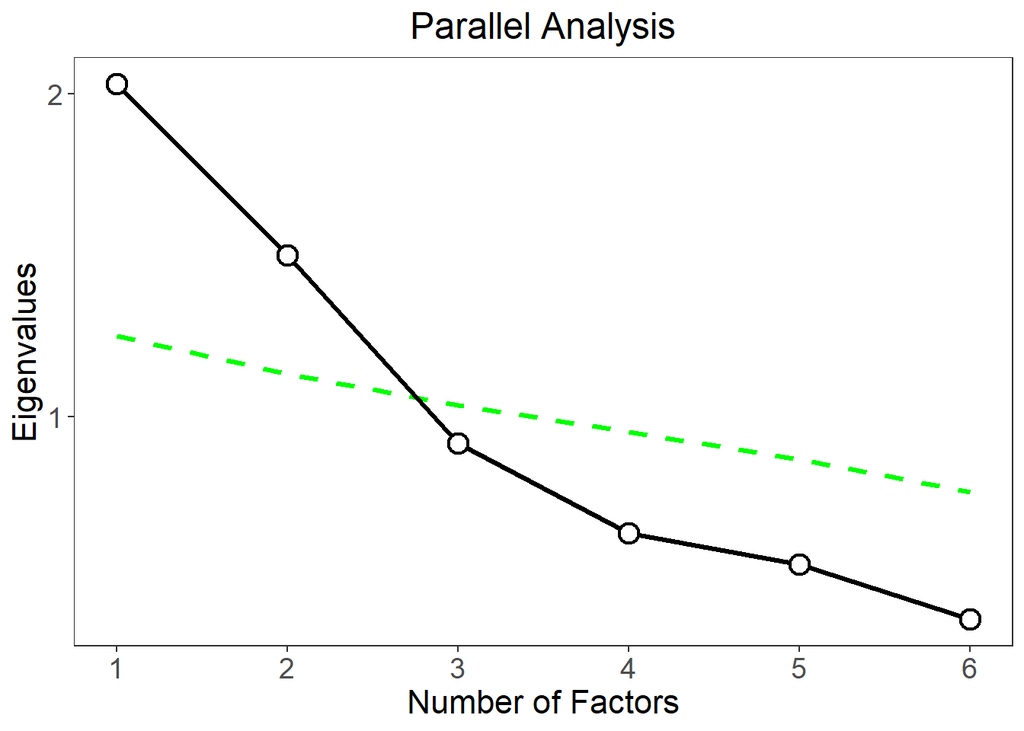

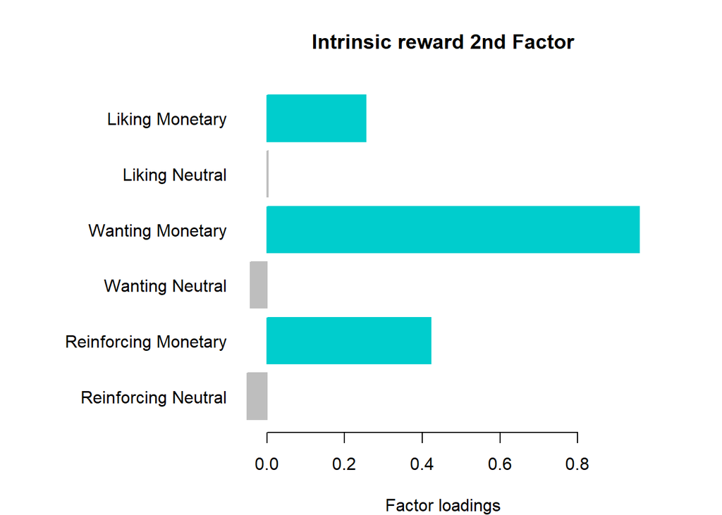

#### Relation to mental health

```
##
## Call:
## lm(formula = mentalHealth_NoOutlier ~ gender + age + iq + edu +
##     income + irSensitivity_NoOutlier + mrSensitivity_NoOutlier,
##     data = df)
##
## Residuals:
##      Min       1Q   Median       3Q      Max
## -2.21971 -0.52089  0.05593  0.62813  1.46940
##
## Coefficients:
##                          Estimate Std. Error t value Pr(>|t|)
## (Intercept)             -0.411264   0.293780  -1.400   0.1636
## gender                   0.046906   0.131507   0.357   0.7218
## age                      0.007526   0.005589   1.347   0.1800
## iq                      -0.025362   0.018765  -1.352   0.1785
## edu                      0.042643   0.038163   1.117   0.2656
## income                   0.081398   0.036912   2.205   0.0289 *
## irSensitivity_NoOutlier  0.196734   0.085891   2.291   0.0233 *
## mrSensitivity_NoOutlier -0.129707   0.074157  -1.749   0.0823 .
## ---
## Signif. codes:  0 '***' 0.001 '**' 0.01 '*' 0.05 '.' 0.1 ' ' 1
##
## Residual standard error: 0.7902 on 154 degrees of freedom
##   (2 observations deleted due to missingness)
## Multiple R-squared:  0.1139, Adjusted R-squared:  0.07366
## F-statistic: 2.829 on 7 and 154 DF,  p-value: 0.008421
```

```
##
## Call:
## lm(formula = mentalHealth_NoOutlier ~ irSensitivity_NoOutlier +
##     mrSensitivity_NoOutlier, data = df)
##
## Residuals:
##      Min       1Q   Median       3Q      Max
## -1.96532 -0.56996  0.05699  0.64743  1.69199
##
## Coefficients:
##                         Estimate Std. Error t value Pr(>|t|)
## (Intercept)              0.07823    0.06362   1.230   0.2206
## irSensitivity_NoOutlier  0.20013    0.08661   2.311   0.0221 *
## mrSensitivity_NoOutlier -0.12465    0.07314  -1.704   0.0903 .
## ---
## Signif. codes:  0 '***' 0.001 '**' 0.01 '*' 0.05 '.' 0.1 ' ' 1
##
## Residual standard error: 0.8093 on 161 degrees of freedom
## Multiple R-squared:  0.04315,    Adjusted R-squared:  0.03126
## F-statistic:  3.63 on 2 and 161 DF,  p-value: 0.0287
```

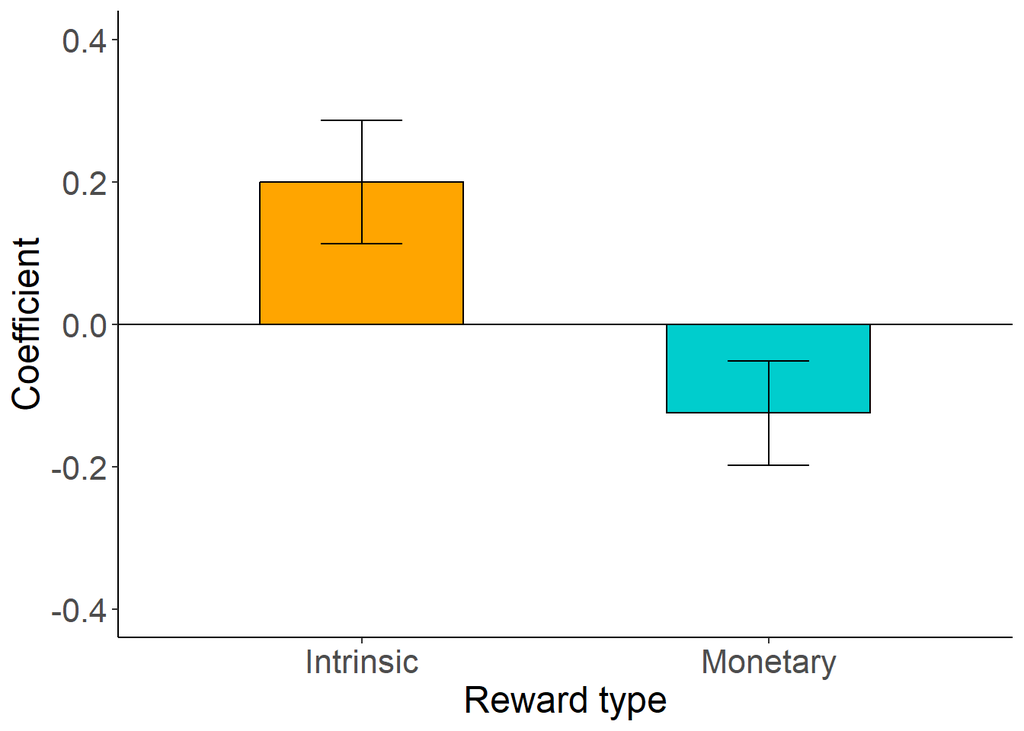

```
##
## Call:
## lm(formula = mentalHealth_NoOutlier ~ irSensitivity_NoOutlier,
##     data = df)
##
## Residuals:
##      Min       1Q   Median       3Q      Max
## -2.04102 -0.60238  0.05221  0.67122  1.62236
##
## Coefficients:
##                         Estimate Std. Error t value Pr(>|t|)
## (Intercept)              0.07601    0.06398   1.188   0.2365
## irSensitivity_NoOutlier  0.17888    0.08621   2.075   0.0396 *
## ---
## Signif. codes:  0 '***' 0.001 '**' 0.01 '*' 0.05 '.' 0.1 ' ' 1
##
## Residual standard error: 0.814 on 162 degrees of freedom
## Multiple R-squared:  0.02589,    Adjusted R-squared:  0.01987
## F-statistic: 4.305 on 1 and 162 DF,  p-value: 0.03958
```

```
##
## Call:
## lm(formula = mentalHealth_NoOutlier ~ gender + age + iq + edu +
##     income + irSensitivity_NoOutlier, data = df)
##
## Residuals:
##      Min       1Q   Median       3Q      Max
## -2.23742 -0.54013  0.04425  0.64997  1.40827
##
## Coefficients:
##                          Estimate Std. Error t value Pr(>|t|)
## (Intercept)             -0.350812   0.293672  -1.195   0.2341
## gender                   0.043872   0.132366   0.331   0.7408
## age                      0.006617   0.005601   1.181   0.2393
## iq                      -0.030504   0.018656  -1.635   0.1041
## edu                      0.044450   0.038402   1.158   0.2488
## income                   0.084112   0.037124   2.266   0.0249 *
## irSensitivity_NoOutlier  0.179074   0.085860   2.086   0.0386 *
## ---
## Signif. codes:  0 '***' 0.001 '**' 0.01 '*' 0.05 '.' 0.1 ' ' 1
##
## Residual standard error: 0.7955 on 155 degrees of freedom
##   (2 observations deleted due to missingness)
## Multiple R-squared:  0.09633,    Adjusted R-squared:  0.06135
## F-statistic: 2.754 on 6 and 155 DF,  p-value: 0.0143
```

```
##
## Call:
## lm(formula = mentalHealth_NoOutlier ~ mrSensitivity_NoOutlier,
##     data = df)
##
## Residuals:
##     Min      1Q  Median      3Q     Max
## -2.0037 -0.6249  0.0533  0.6974  1.5353
##
## Coefficients:
##                         Estimate Std. Error t value Pr(>|t|)
## (Intercept)              0.09427    0.06408   1.471    0.143
## mrSensitivity_NoOutlier -0.10032    0.07334  -1.368    0.173
##
## Residual standard error: 0.82 on 162 degrees of freedom
## Multiple R-squared:  0.01142,    Adjusted R-squared:  0.005317
## F-statistic: 1.871 on 1 and 162 DF,  p-value: 0.1732
```

```
##
## Call:
## lm(formula = mentalHealth_NoOutlier ~ gender + age + iq + edu +
##     income + mrSensitivity_NoOutlier, data = df)
##
## Residuals:
##      Min       1Q   Median       3Q      Max
## -2.06684 -0.52495  0.07945  0.58109  1.58125
##
## Coefficients:
##                          Estimate Std. Error t value Pr(>|t|)
## (Intercept)             -0.473046   0.296519  -1.595   0.1127
## gender                   0.055927   0.133236   0.420   0.6752
## age                      0.008766   0.005638   1.555   0.1220
## iq                      -0.021499   0.018944  -1.135   0.2582
## edu                      0.035858   0.038566   0.930   0.3539
## income                   0.086081   0.037357   2.304   0.0225 *
## mrSensitivity_NoOutlier -0.109739   0.074644  -1.470   0.1435
## ---
## Signif. codes:  0 '***' 0.001 '**' 0.01 '*' 0.05 '.' 0.1 ' ' 1
##
## Residual standard error: 0.801 on 155 degrees of freedom
##   (2 observations deleted due to missingness)
## Multiple R-squared:  0.08375,    Adjusted R-squared:  0.04828
## F-statistic: 2.361 on 6 and 155 DF,  p-value: 0.03281
```

```
## [1] 419.1394
```

```
## [1] 421.3798
```

```
## [1] 0
```

```
## [1] 2.240336
```

```
## [1] 411.2045
```

```
## [1] 413.6225
```

```
## [1] 0
```

```
## [1] 2.417964
```

```
##                                 RewardFactorCoefficients standard_errors
## Intrinsic reward (with dem.)                   0.2064247      0.08720987
## Monetary reward (with dem.)                    0.1326325      0.11102134
## Intrinsic reward (without dem.)                0.1928759      0.08476793
## Monetary reward (without dem.)                 0.1139031      0.10792138
##                                 degrees_of_freedom t_values   p_values      BIC
## Intrinsic reward (with dem.)                   113 2.366987 0.01963430 295.2102
## Monetary reward (with dem.)                    113 1.194657 0.23472241 299.5110
## Intrinsic reward (without dem.)                119 2.275341 0.02467504 282.9349
## Monetary reward (without dem.)                 119 1.055426 0.29336843 286.9604
##                                 deltaBIC
## Intrinsic reward (with dem.)    0.000000
## Monetary reward (with dem.)     4.300775
## Intrinsic reward (without dem.) 0.000000
## Monetary reward (without dem.)  4.025515
```

```
##                                 RewardFactorCoefficients standard_errors
## Intrinsic reward (with dem.)                  0.22702424      0.06789445
## Monetary reward (with dem.)                   0.03543065      0.09545515
## Intrinsic reward (without dem.)               0.20398050      0.07120948
## Monetary reward (without dem.)                0.05186141      0.10159449
##                                 degrees_of_freedom  t_values    p_values
## Intrinsic reward (with dem.)                   147 3.3437822 0.001048612
## Monetary reward (with dem.)                    147 0.3711759 0.711040909
## Intrinsic reward (without dem.)                153 2.8645134 0.004763766
## Monetary reward (without dem.)                 153 0.5104746 0.610454716
##                                      BIC  deltaBIC
## Intrinsic reward (with dem.)    351.9627  0.000000
## Monetary reward (with dem.)     363.1076 11.144951
## Intrinsic reward (without dem.) 361.0712  0.000000
## Monetary reward (without dem.)  368.9049  7.833688
```

```
##                                 RewardFactorCoefficients standard_errors
## Intrinsic reward (with dem.)                   0.1790738      0.08586029
## Monetary reward (with dem.)                   -0.1097394      0.07464433
## Intrinsic reward (without dem.)                0.1788807      0.08621097
## Monetary reward (without dem.)                -0.1003223      0.07333710
##                                 degrees_of_freedom  t_values   p_values
## Intrinsic reward (with dem.)                   155  2.085642 0.03864966
## Monetary reward (with dem.)                    155 -1.470165 0.14354419
## Intrinsic reward (without dem.)                162  2.074918 0.03957520
## Monetary reward (without dem.)                 162 -1.367962 0.17321864
##                                      BIC deltaBIC
## Intrinsic reward (with dem.)    419.1394 0.000000
## Monetary reward (with dem.)     421.3798 2.240336
## Intrinsic reward (without dem.) 411.2045 0.000000
## Monetary reward (without dem.)  413.6225 2.417964
```

## Comparing intrinsic rewards versus monetary rewards reducing triplets

### Experiment 1

#### Monetary & visual & neutral

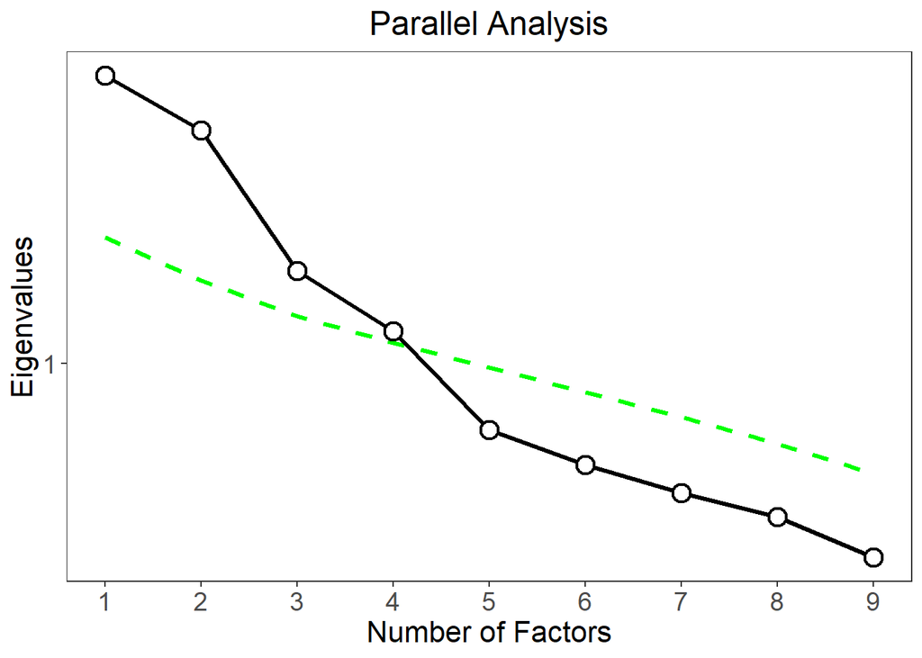

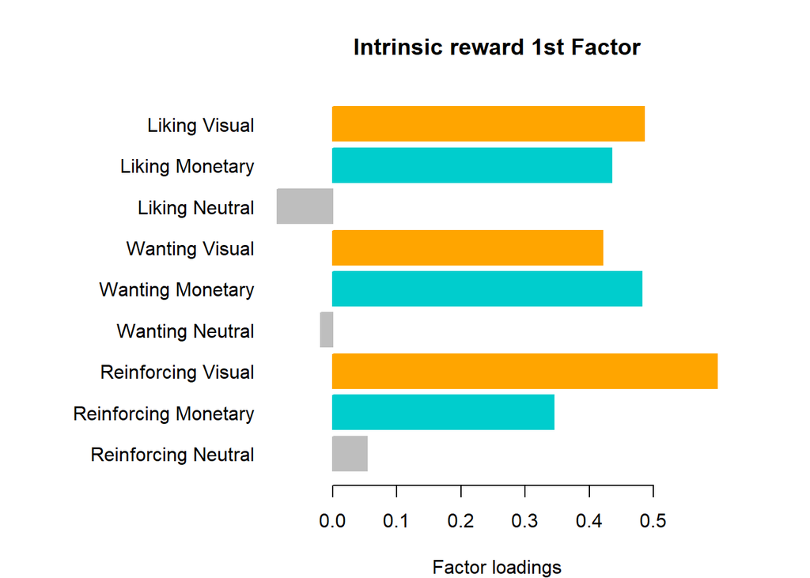

#### Monetary & Cognitive & neutral

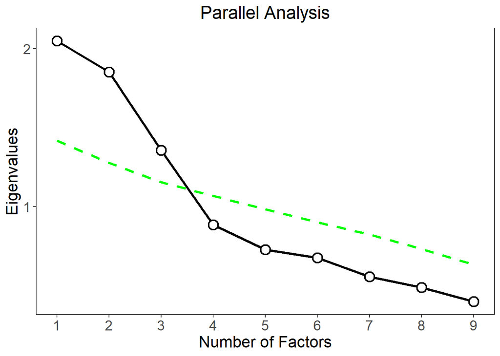

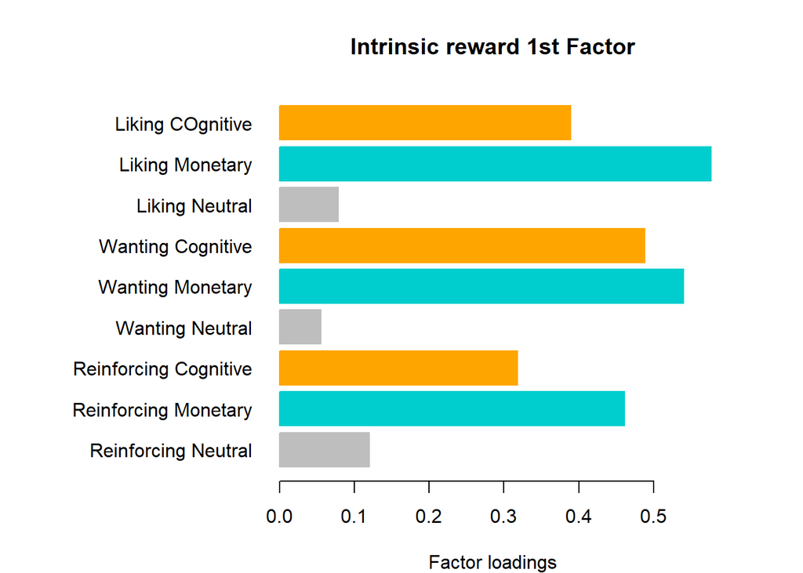

#### Monetary & Social & neutral

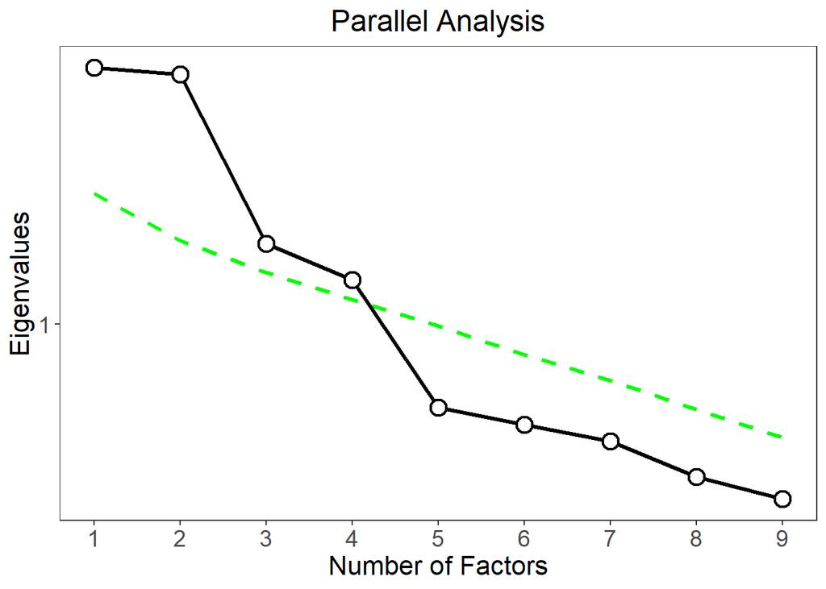

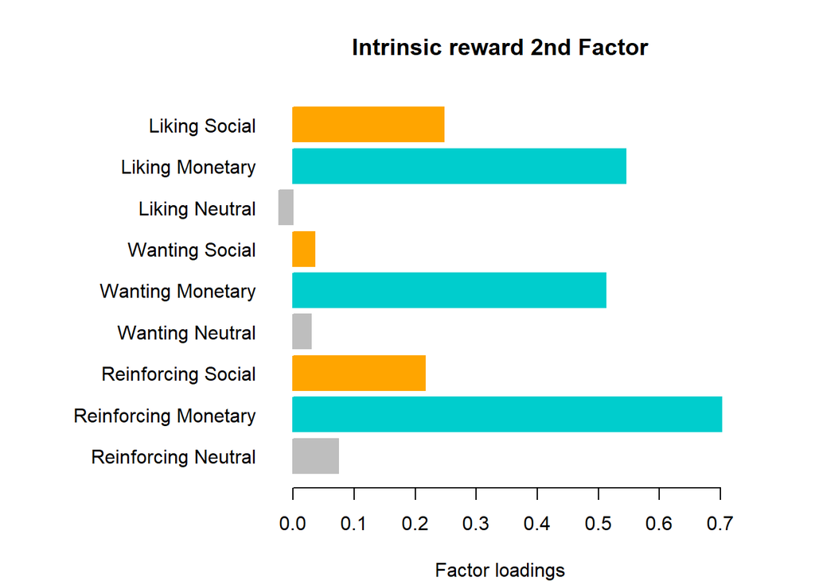

#### Cognitive & visual & neutral

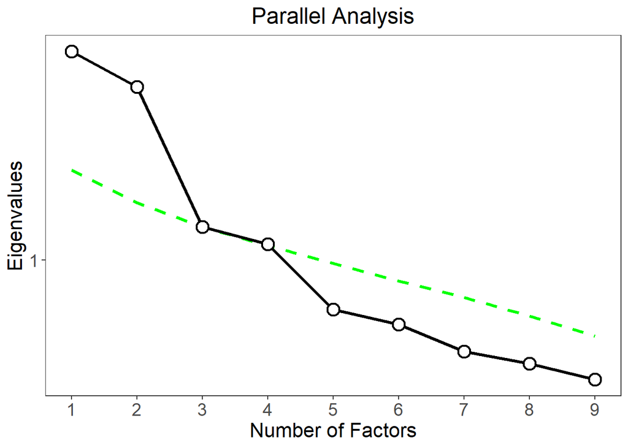

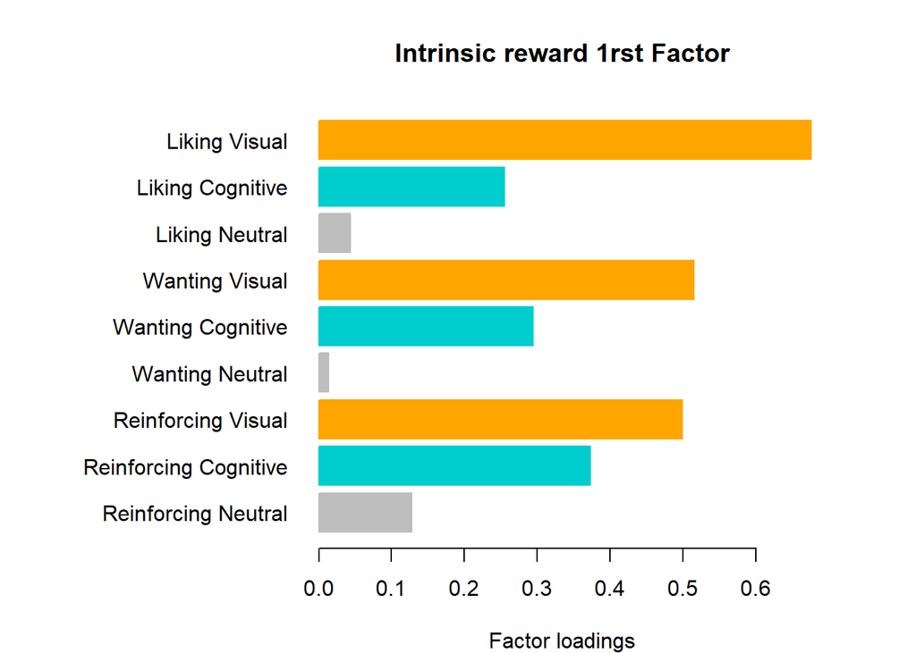

#### Visual & Social & Neutral

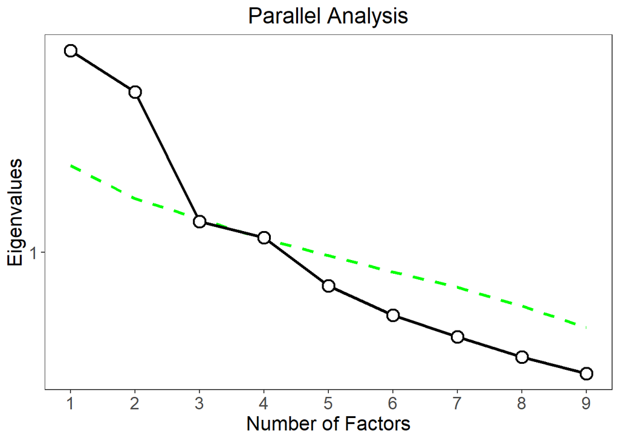

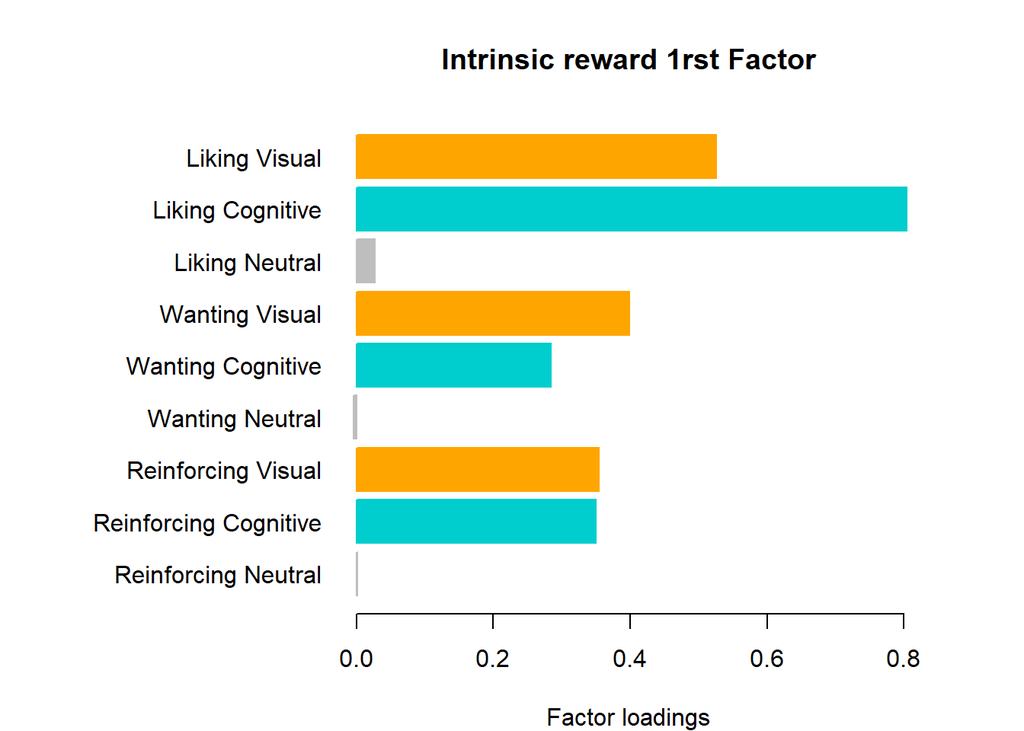

### Cognitive & Social & Neutral

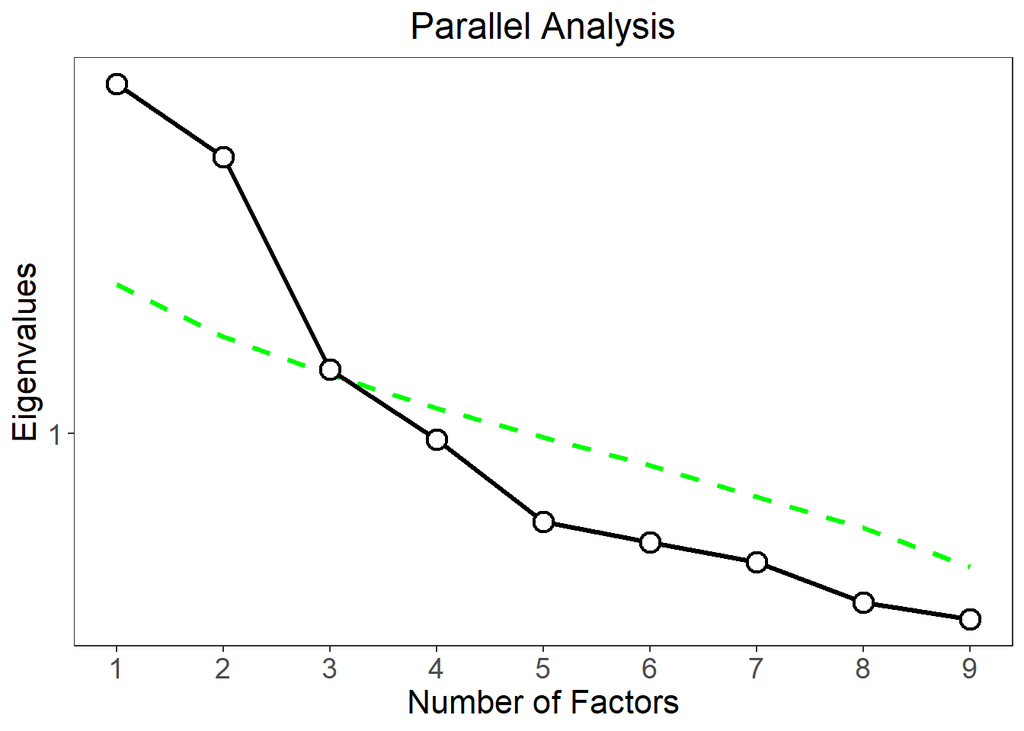

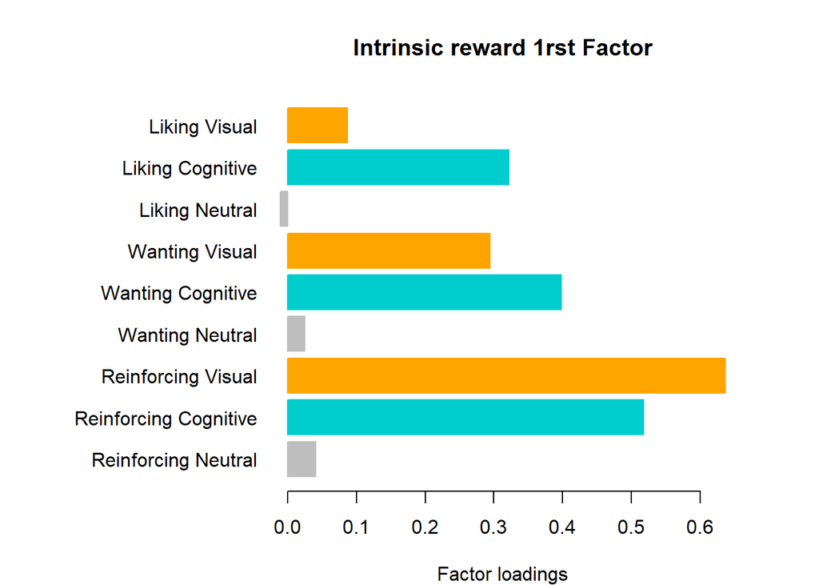

## Run the regressions and compare the model families

```
## [1] 1148.816
```

```
## [1] 1159.08
```

```
## [1] 10.26451
```

```
## [1] 1126.144
```

```
## [1] 1132.949
```

```
## [1] 6.805027
```

### Experiment 2

#### Monetary & visual & neutral

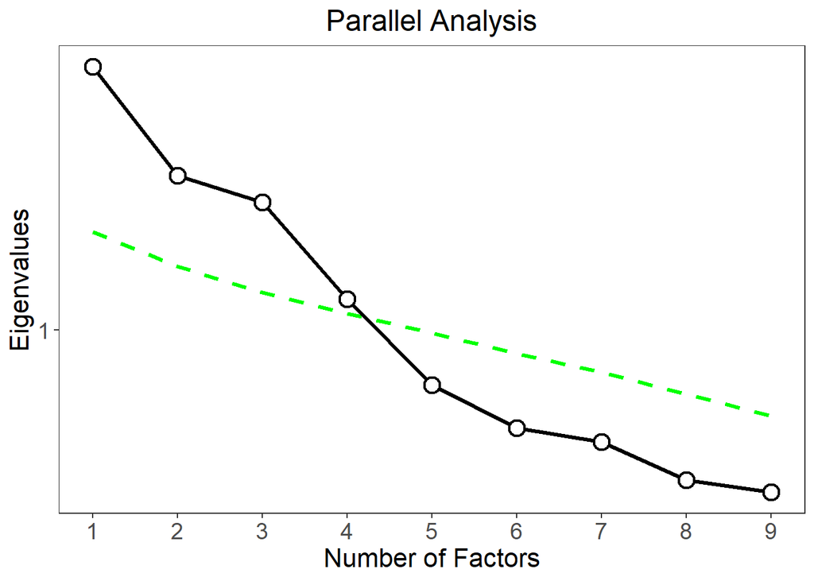

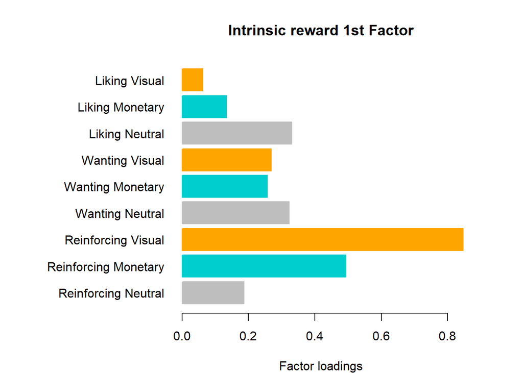

#### Monetary & Cognitive & neutral

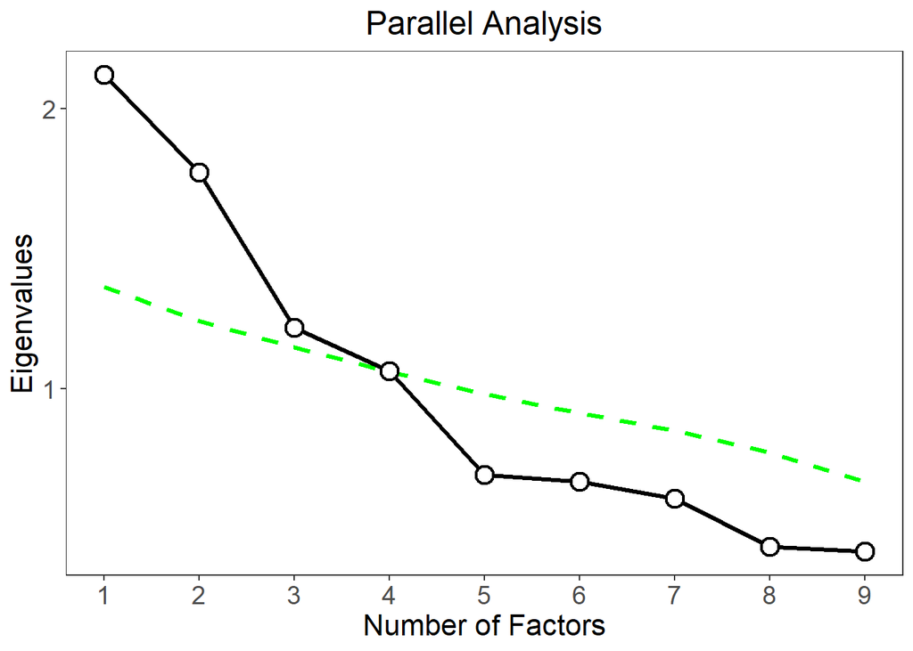

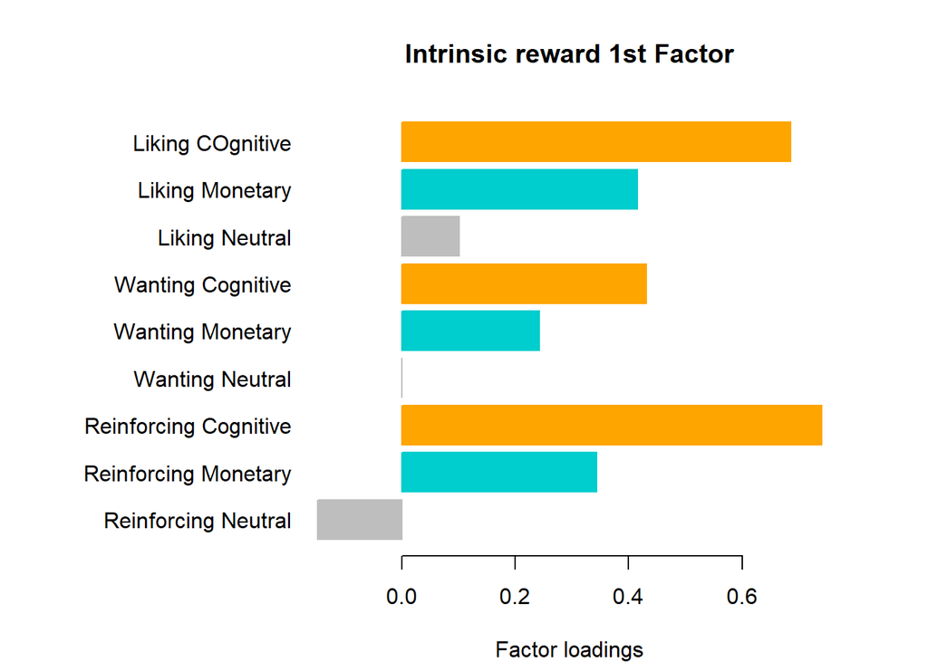

#### Monetary & Social & neutral

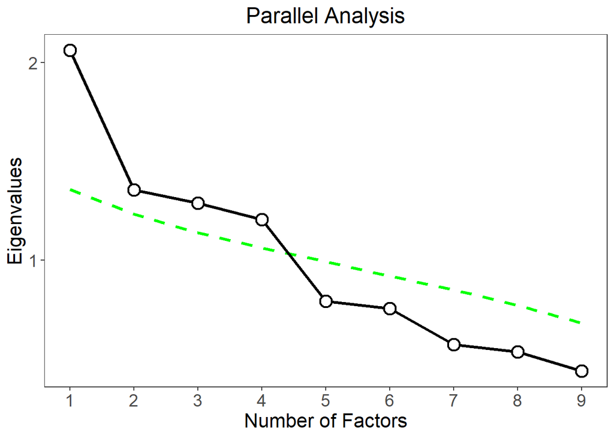

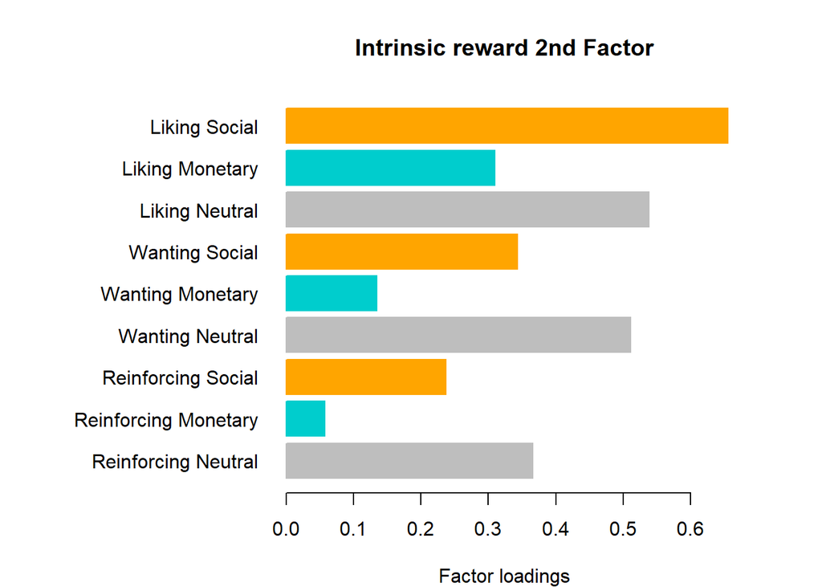

#### Cognitive & visual & neutral

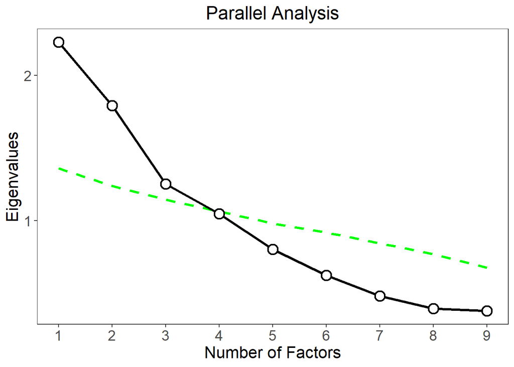

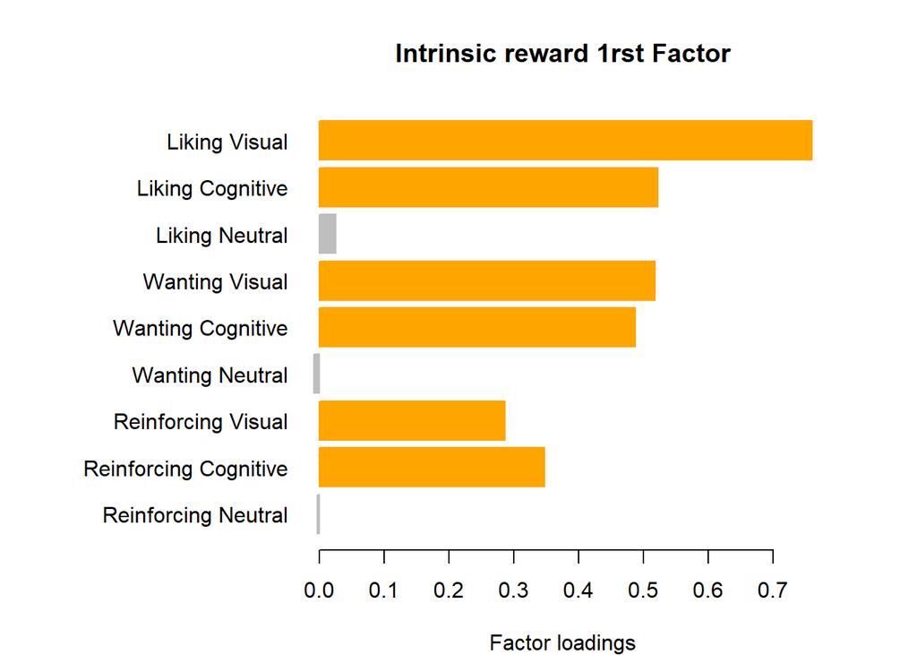

#### Visual & Social & Neutral

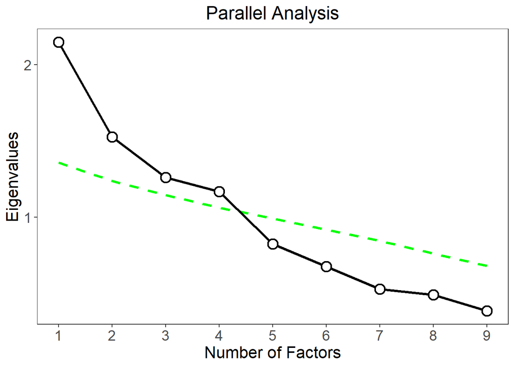

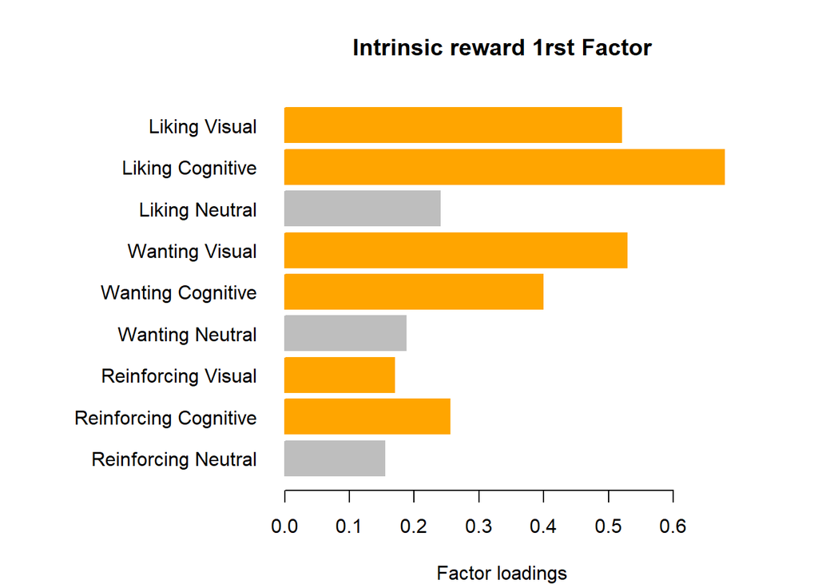

### Cognitive & Social & Neutral

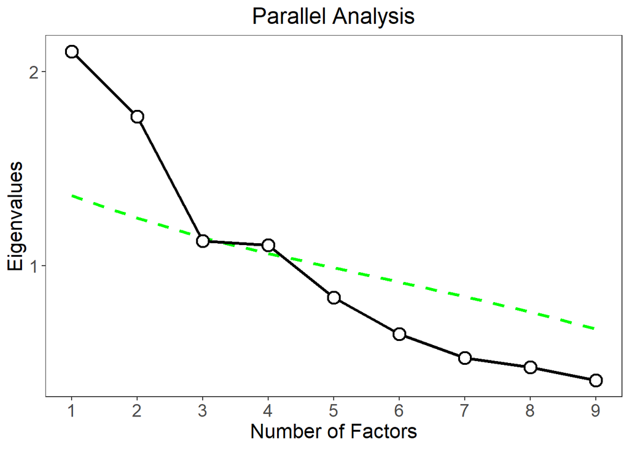

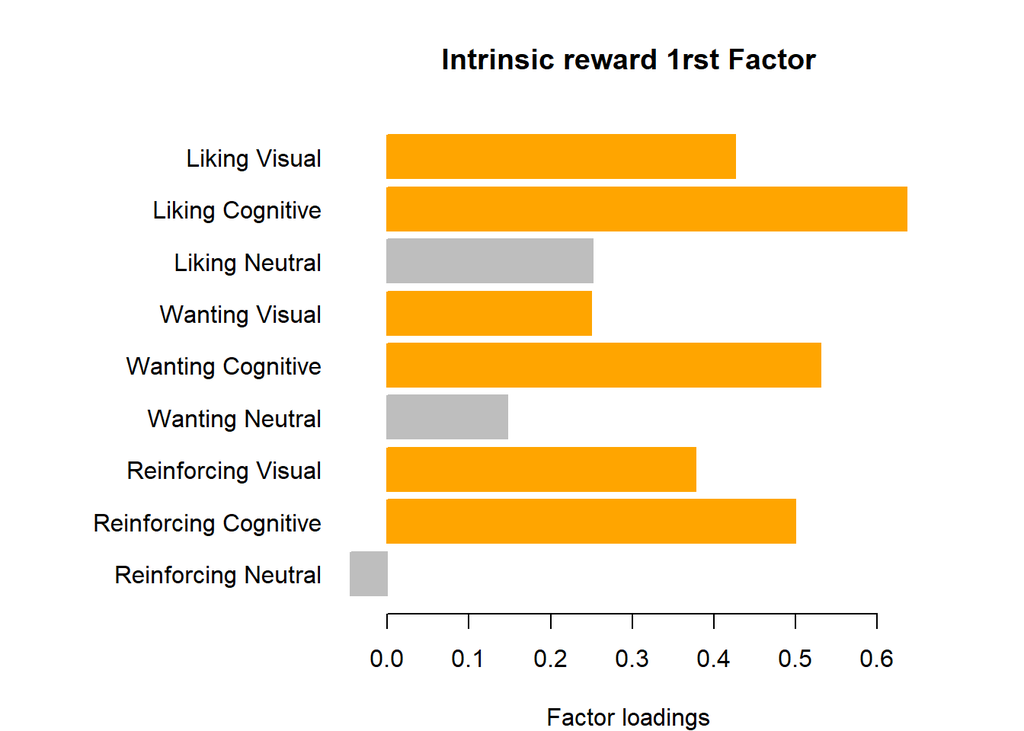

## Run the regressions and compare the model families

```
## [1] 1456.387
```

```
## [1] 1457.81
```

```
## [1] 1.422411
```

```
## [1] 1485.665
```

```
## [1] 1487.582
```

```
## [1] 1.916868
```

### Experiment 3

#### Monetary & visual & neutral

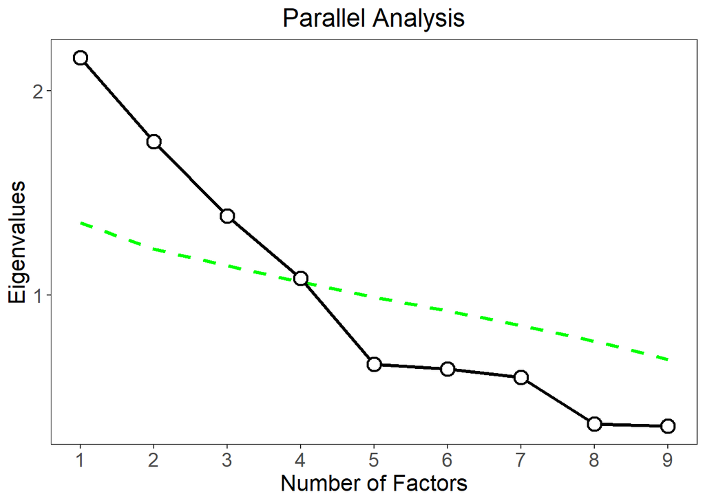

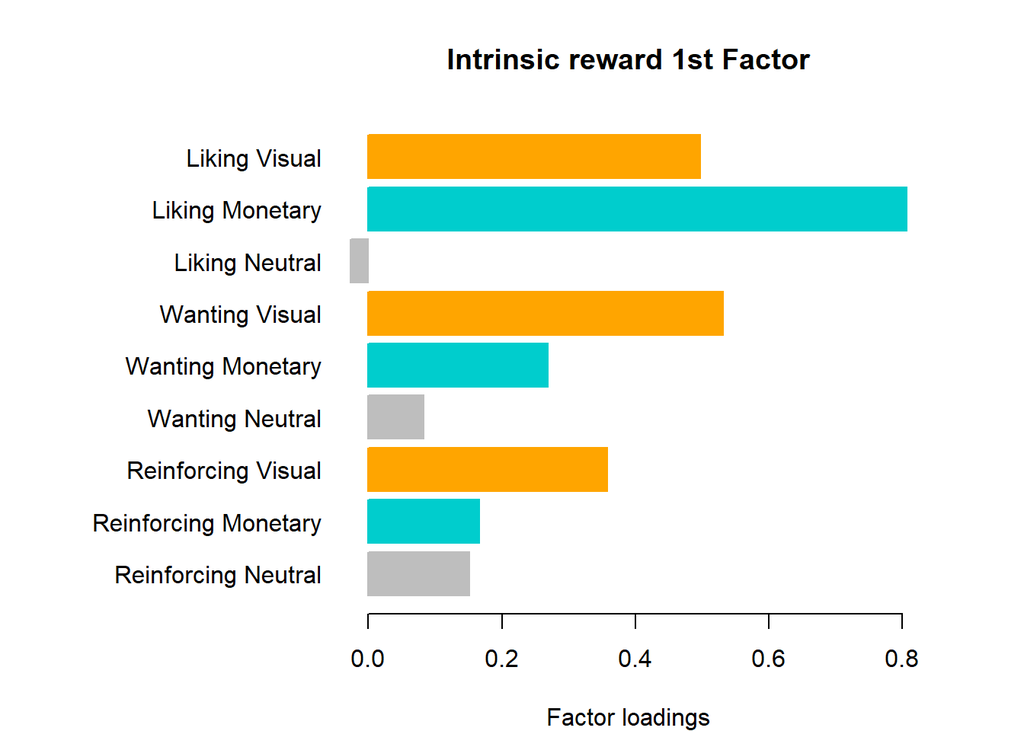

#### Monetary & Cognitive & neutral

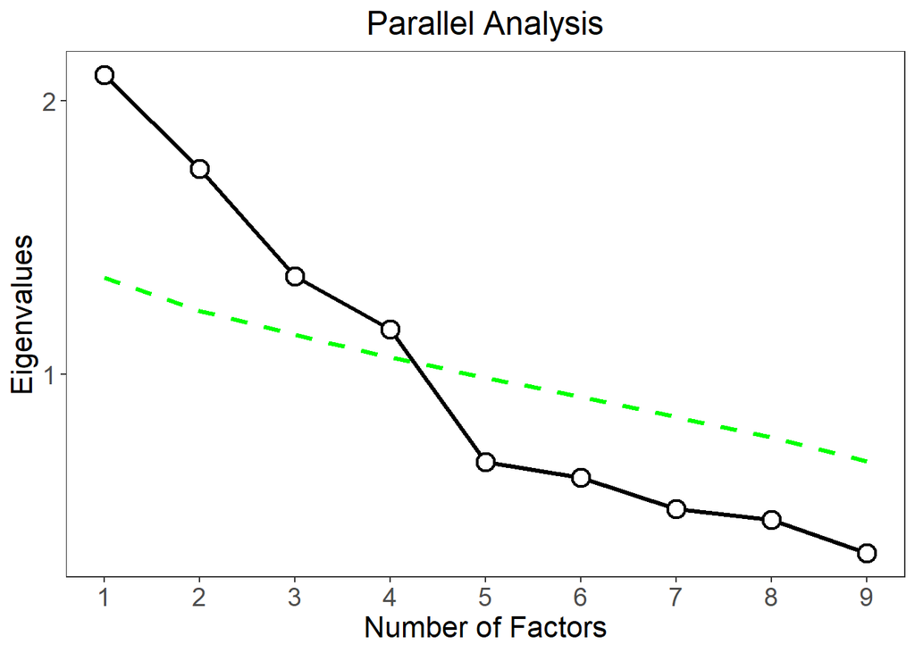

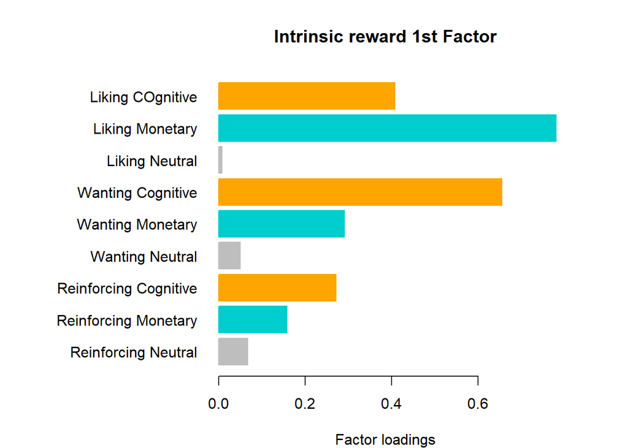

#### Monetary & Social & neutral

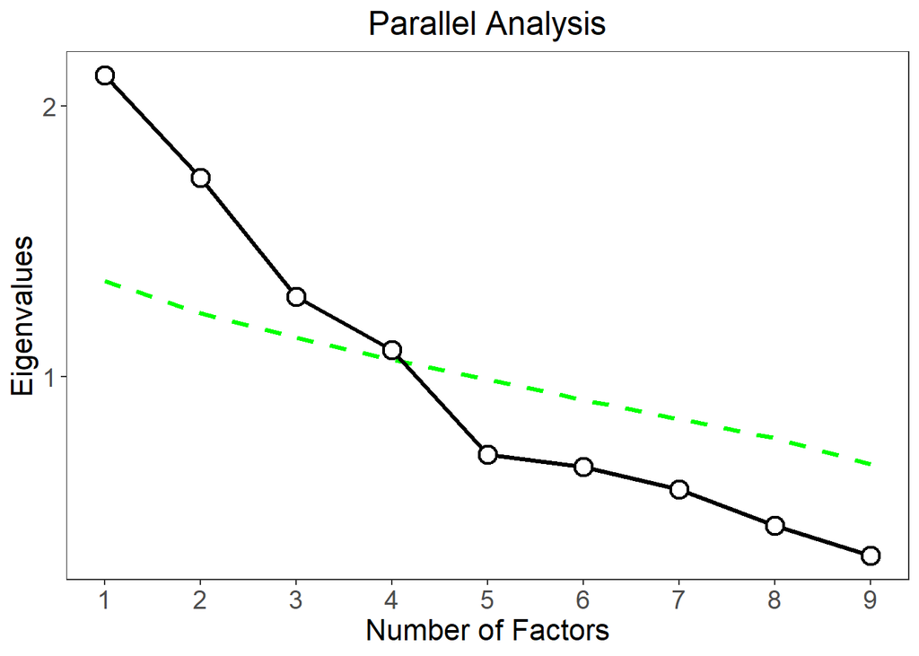

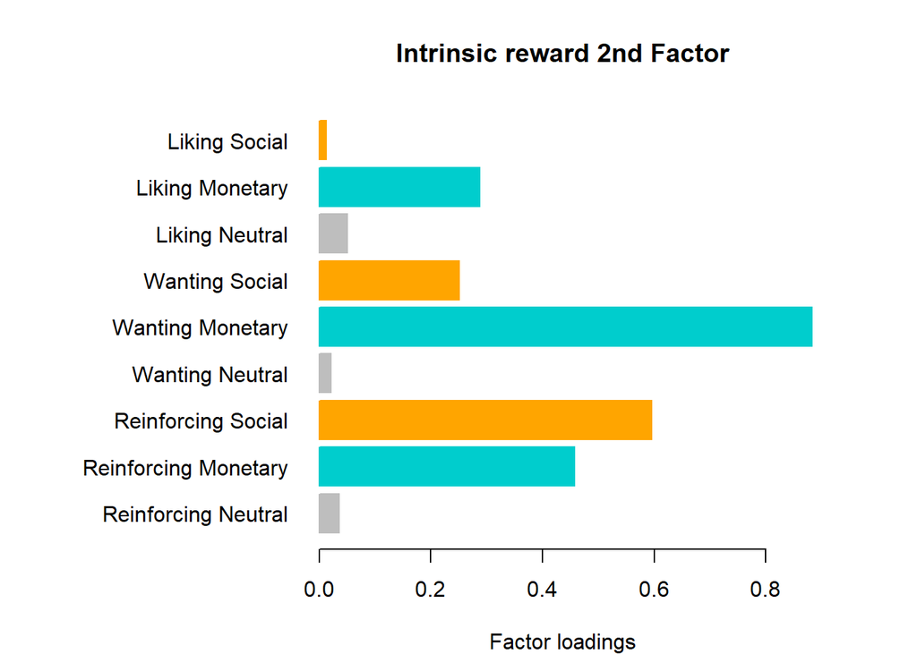

#### Cognitive & visual & neutral

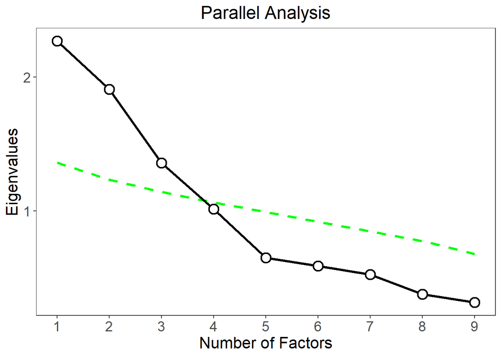

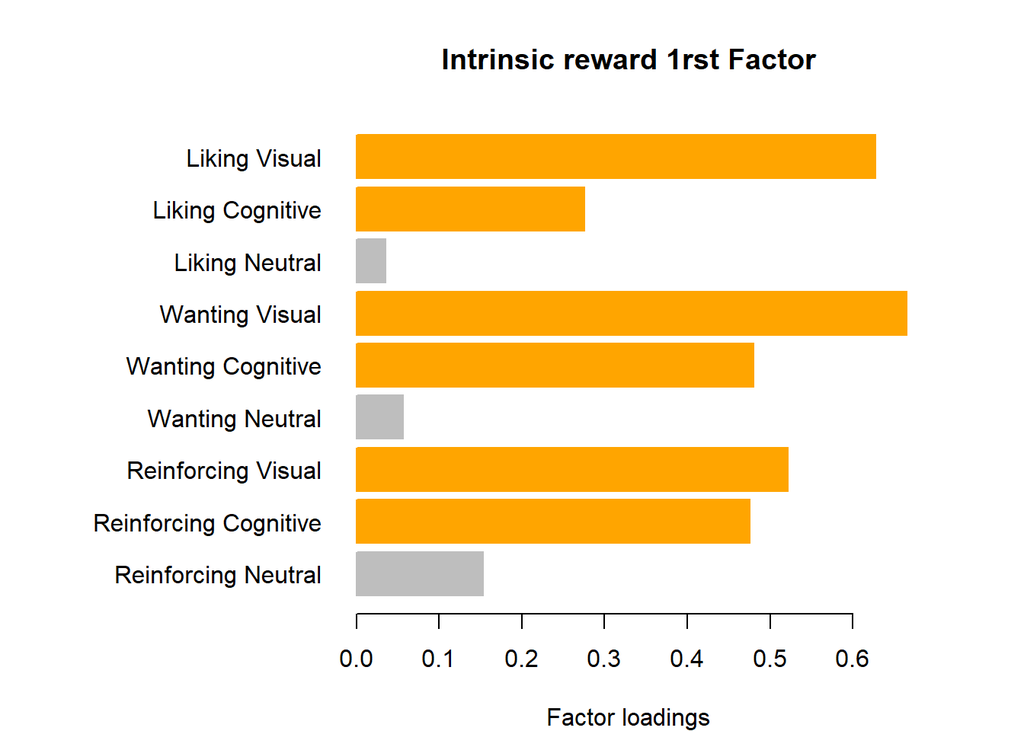

#### Visual & Social & Neutral

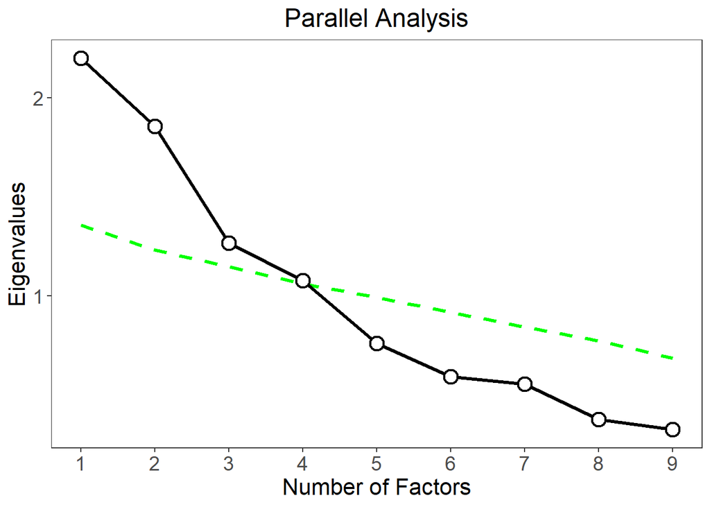

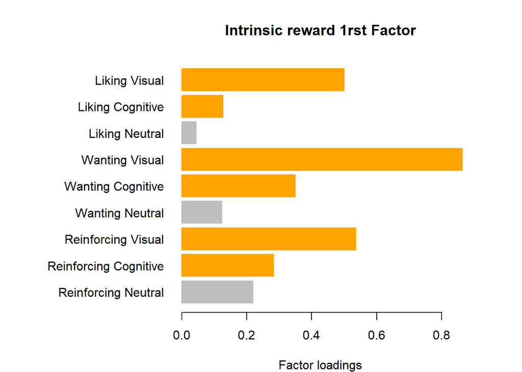

### Cognitive & Social & Neutral

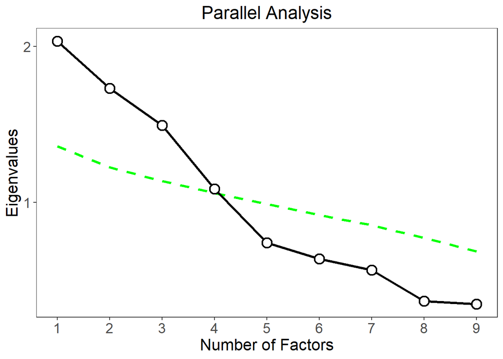

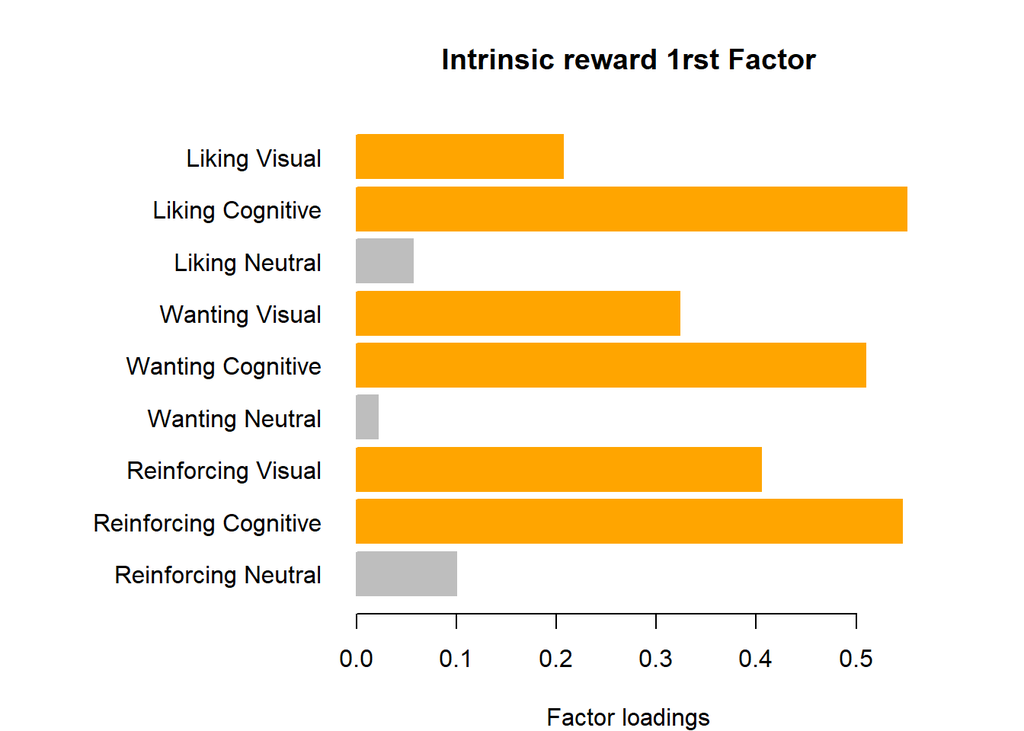

## Run the regressions and compare the model families

```
## [1] 1525.414
```

```
## [1] 1531.184
```

```
## [1] 5.769734
```

```
## [1] 1541.286
```

```
## [1] 1546.839
```

```
## [1] 5.553095
```